# R Notebook

# Spearman Correlations

### Watershed Characteristics

Soil Erodibility Factor and Mean Soil Erodibility were significantly correlated with the other watershed characteristics (r > 0.5), and therefore, were removed from the analysis.

|  | Area | Karst | Precip | Soil Erodibility Factor | Mean Soil Erodibility | Physiographic Province | Average Watershed Slope | Soil Group | Ecoregion | Ecoregion4 | Ecoregion3 |
| --- | --- | --- | --- | --- | --- | --- | --- | --- | --- | --- | --- |
| Area | 1.00 |  |  |  |  |  |  |  |  |  |  |
| Karst | 0.21 | 1 |  |  |  |  |  |  |  |  |  |
| Precip | -0.11 | -0.17 | 1 |  |  |  |  |  |  |  |  |
| Soil Erodibility Factor | -0.14 | 0.22 | 0.39 | 1 |  |  |  |  |  |  |  |
| Mean Soil Erodibility | -0.03 | 0.11 | 0.34 | 0.64 | 1 |  |  |  |  |  |  |
| Physiographic Province | 0.14 | 0.42 | -0.71 | -0.2 | -0.3 | 1 |  |  |  |  |  |
| Average Watershed Slope | 0.13 | -0.19 | -0.42 | -0.76 | -0.73 | 0.27 | 1 |  |  |  |  |
| Soil Group | -0.07 | -0.12 | 0.04 | 0.06 | 0.04 | -0.05 | -0.13 | 1 |  |  |  |
| Ecoregion | -0.06 | 0.26 | 0.17 | 0.58 | 0.47 | -0.02 | -0.62 | 0.1 | 1 |  |  |
| Ecoregion4 | -0.08 | -0.26 | -0.37 | -0.56 | -0.56 | 0.28 | 0.64 | 0.01 | -0.67 | 1 |  |
| Ecoregion3 | -0.06 | 0.16 | -0.35 | -0.3 | -0.43 | 0.42 | 0.44 | -0.02 | -0.29 | 0.78 | 1 |

## Alteration x Alteration

In both scenarios 3-Day Minimum (cfs/sqmi), Extreme Low Flow Frequency, and Extreme Low Flow Duration were ignored because they were not present in the Phase 1 analysis or the Middle Potomac study. In subsequent analyses, these three alteration metrics were removed.

In the Baseline/Current scenario Flashiness was significantly correlated (r > 0.50) with MH21, DH17, High Pulse Count, and 3-Day Maximum (cfs/sqmi). However, in the Baseline/Impervious scenario Flashiness was only significantly correlated with High Pulse Count and 3-Day Maximum (cfs/sqmi). DH17 and MH21 were significantly correlated (r = 0.86). MH21 was excluded becuase it was slightly more correlated with Flashiness (r = -0.40). Flashiness and DH17 were retained for further analysis.

In both scenarios, Low Pulse Duration was not significantly correlated with any of the other alteration metrics. Therefore, Low Pulse Duration was retained for further analyses.

### Baseline/Current Scenario

|  | High flow index, MH21 (days) | High flow duration, DH17 (days) | High pulse count (#) | Flashiness (ratio) | Low pulse duration (days) | 3-day maximum (cfs/sqmi) | 3-day minimum (cfs/sqmi) | Extreme low flow frequency | Extreme low flow duration |
| --- | --- | --- | --- | --- | --- | --- | --- | --- | --- |
| High flow index, MH21 (days) | 1.00 |  |  |  |  |  |  |  |  |
| High flow duration, DH17 (days) | 0.93 | 1 |  |  |  |  |  |  |  |
| High pulse count (#) | -0.81 | -0.8 | 1 |  |  |  |  |  |  |
| Flashiness (ratio) | -0.88 | -0.89 | 0.91 | 1 |  |  |  |  |  |
| Low pulse duration (days) | 0.47 | 0.46 | -0.41 | -0.43 | 1 |  |  |  |  |
| 3-day maximum (cfs/sqmi) | -0.82 | -0.83 | 0.91 | 0.95 | -0.41 | 1 |  |  |  |
| 3-day minimum (cfs/sqmi) | -0.08 | 0 | 0.03 | 0.03 | -0.04 | 0.12 | 1 |  |  |
| Extreme low flow frequency | -0.14 | -0.21 | 0.25 | 0.25 | -0.05 | 0.2 | -0.72 | 1 |  |
| Extreme low flow duration | 0.45 | 0.41 | -0.48 | -0.48 | 0.31 | -0.51 | -0.1 | -0.11 | 1 |

### Baseline/Impervious Scenario

|  | High flow index, MH21 (days) | High flow duration, DH17 (days) | High pulse count (#) | Flashiness (ratio) | Low pulse duration (days) | 3-day maximum (cfs/sqmi) | 3-day minimum (cfs/sqmi) | Extreme low flow frequency | Extreme low flow duration |
| --- | --- | --- | --- | --- | --- | --- | --- | --- | --- |
| High flow index, MH21 (days) | 1.00 |  |  |  |  |  |  |  |  |
| High flow duration, DH17 (days) | 0.86 | 1 |  |  |  |  |  |  |  |
| High pulse count (#) | -0.60 | -0.53 | 1 |  |  |  |  |  |  |
| Flashiness (ratio) | -0.40 | -0.39 | 0.84 | 1 |  |  |  |  |  |
| Low pulse duration (days) | 0.07 | -0.01 | -0.1 | -0.16 | 1 |  |  |  |  |
| 3-day maximum (cfs/sqmi) | -0.21 | -0.22 | 0.7 | 0.73 | -0.09 | 1 |  |  |  |
| 3-day minimum (cfs/sqmi) | 0.05 | 0.05 | -0.18 | -0.33 | 0.36 | -0.26 | 1 |  |  |
| Extreme low flow frequency | 0.06 | 0.07 | 0.28 | 0.3 | -0.15 | 0.35 | -0.31 | 1 |  |
| Extreme low flow duration | 0.00 | -0.03 | -0.27 | -0.31 | 0.37 | -0.22 | 0.48 | -0.38 | 1 |

## Alteration x Watershed Characteristic

In both scenarios Low Pulse Duration was not significantly correlated (-0.5 < r < 0.5) with any watershed characteristics.

In the Baseline/Current scenario, DH17 was significantly correlated with Soil Erodibility Factor, Mean Soil Erodbility. However, DH17 was not signficantly correlated with any watershed characteristics in the Baseline/Impervious scenario.

### Baseline/Current Scenario

|  | Area | Karst | Precip | Soil Erodibility Factor | Mean Soil Erodibility | Physiographic Province | Average Watershed Slope | Soil Group |
| --- | --- | --- | --- | --- | --- | --- | --- | --- |
| High flow index, MH21 (days) | 0.07 | -0.30 | -0.16 | -0.63 | -0.49 | -0.01 | 0.66 | -0.07 |
| High flow duration, DH17 (days) | 0.12 | -0.22 | -0.24 | -0.67 | -0.50 | 0.07 | 0.68 | -0.10 |
| High pulse count (#) | -0.16 | 0.28 | 0.37 | 0.76 | 0.59 | -0.14 | -0.74 | 0.06 |
| Flashiness (ratio) | -0.11 | 0.24 | 0.44 | 0.79 | 0.64 | -0.21 | -0.81 | 0.06 |
| Low pulse duration (days) | -0.06 | -0.17 | -0.12 | -0.34 | -0.23 | 0.02 | 0.27 | 0.00 |
| 3-day maximum (cfs/sqmi) | -0.11 | 0.30 | 0.37 | 0.80 | 0.65 | -0.14 | -0.81 | 0.00 |

### Baseline/Impervious Scenario

|  | Area | Karst | Precip | Soil Erodibility Factor | Mean Soil Erodibility | Physiographic Province | Average Watershed Slope | Soil Group |
| --- | --- | --- | --- | --- | --- | --- | --- | --- |
| High flow index, MH21 (days) | -0.05 | -0.49 | 0.43 | 0.04 | 0.12 | -0.49 | -0.01 | 0.07 |
| High flow duration, DH17 (days) | -0.07 | -0.47 | 0.33 | -0.03 | 0.06 | -0.39 | 0.05 | -0.02 |
| High pulse count (#) | -0.12 | 0.41 | -0.07 | 0.50 | 0.39 | 0.23 | -0.42 | -0.09 |
| Flashiness (ratio) | -0.14 | 0.32 | 0.28 | 0.65 | 0.45 | -0.03 | -0.56 | -0.04 |
| Low pulse duration (days) | 0.01 | 0.01 | -0.14 | 0.00 | 0.00 | 0.11 | -0.05 | 0.06 |
| 3-day maximum (cfs/sqmi) | -0.15 | 0.22 | 0.16 | 0.53 | 0.47 | 0.02 | -0.49 | 0.07 |

## Alteration x %Impervious Cover

The percent change in Impervious Cover was held constant in the Baseline/Impervious scenario, and therefore, correlations will not exist between the Alteration metrics and the percent change in Impervious cover. Low Pulse Duration was not signficantly correlated with the Percentage of Impervious Cover Change in the Baseline/Current Scenario. Percent Impervious Cover Change was negatively correlated with DH17 and positively correlated with Flashiness in the Baseline/Current scenario.

### Baseline/Current Scenario

|  | Impervious Cover (%) |
| --- | --- |
| High flow index, MH21 (days) | -0.88 |
| High flow duration, DH17 (days) | -0.89 |
| High pulse count (#) | 0.84 |
| Flashiness (ratio) | 0.91 |
| Low pulse duration (days) | -0.46 |
| 3-day maximum (cfs/sqmi) | 0.87 |

# Loess Curves

The color gradient in all loess plots belwo is based on the percentage of impervious cover in the Current scenario. The percentage of impervious cover in each watershed from the Baseline scenario is approximately zero. To create the Impervious Cover scenario, the percentage of impervious cover in each watershed was increased by 10%.

Categorical variables, like FCODE (FCODEgraphic Province) and Soil, are not appropriate for Loess curves. However, I left these plots in because they have the potental to inform patterns in the other plots.

In general, the Baseline/Impervious Loess Curves show similar but weaker trends to the Baseline/Current.

## Flashiness

The relationship beteen Karst and Flashiness appears to be slightly stronger in the Baseline/Impervious scenario. As the percentage of Karst in a watershed increases, Flashiness may also increase.

Slope was negatively correlated with Flashiness in both scenarios (See correlation section). Development is more prominent in flat areas (low slope), therefore, in the Baseline/Current scenario the negative correlation was assumed to be an artifact development bias. Although the Baseline/Imperious scenario correlation was weaker, there does appear to be a negative correlation between Slope and Flashiness, even if the percent change in impervious cover is a constant.

### Baseline/Current Scenario

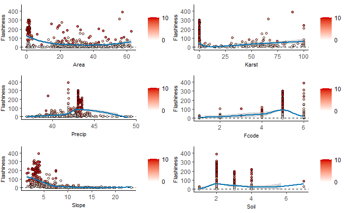

### Baseline/Impervious Scenario

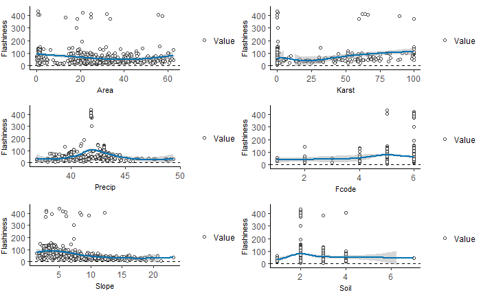

## DH17

Area and Karst had similar distirbutions in both scenarios but the values were generally lower and variability was generally smaller in the Baseline/Impervious scenario.

The Baseline/Current scenario had a concave, almost, biomodal distribution between Precipitation and DH17. This pattern was dramatically reduced in the Baseline/Impervious scenario. There did appear to be a positive relationship between Perceiptation and DH17 for percipitation values greater than 42.

The was a strong positive correlation between Slope and DH17 in the Baseline/Current scenario. However, this relationship did not exist in the Baseline/Impervious scenario. As was stated in the Flashiness section, the relationship observed in the Baseline/Current scenario may be due to a development bias. Development occurs more frequently in flat areas.

### Baseline/Current Scenario

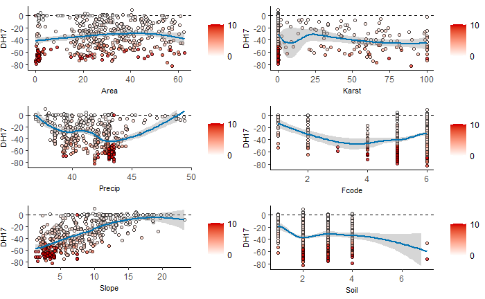

### Baseline/Impervious Scenario

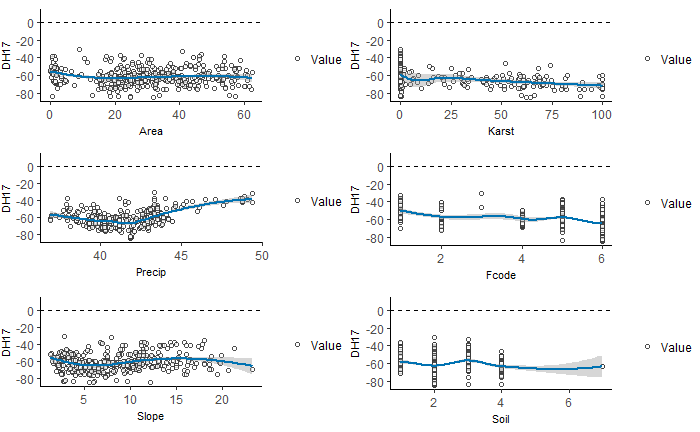

## Low Pulse Duration

Area and Karst had similar distirbutions in both scenarios but the values were generally lower and variability was generally smaller in the Baseline/Impervious scenario.

In the Baseline/Current scenario, the relationship between Precipiation and Low Pulse Duration was a slightly concave unimodal distribution. There was no relationship in the Basline/Impervious scenario and there was generally less variance.

There was a positive relationship between Slope and Low Pulse Duration in the Baseline/Current scenario. There was no relationship observed between Slope and Low Pulse Duration in the Basline/Impervious scenario.

### Baseline/Current Scenario

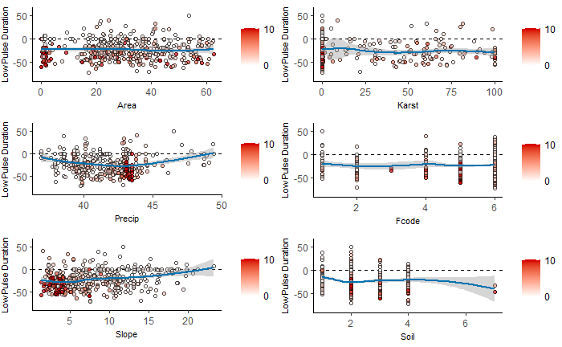

### Baseline/Impervious Scenario

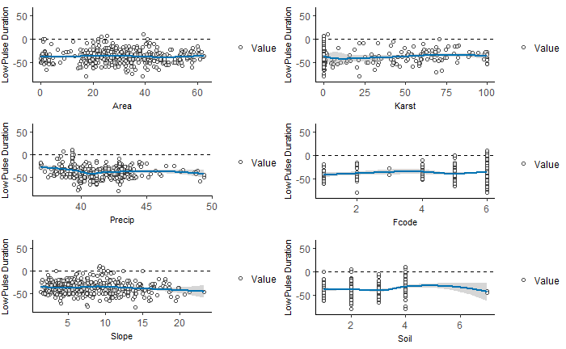

# Random Forest

In the Baseline/Current scenario, Slope was consistently the most important watershed characteristic for predicting Alteration Metric values. Precipiation and Area were also important in the Flashiness Random Forest model. Similaraly, Precipiation was the second most import preditive variable in the Low Pulse Duration Random Forest model.

In the Baseline/Impervious scenario, Slope dropped out as the most important predictive variable and was replaced with Precipiation. Karst was the second most important predictive variable for the DH17 Random Forest model. For the Flashiness Random Forest model, Slope and Karst were also important predictive variables. Slope was the second most important predictive variable for the Low Pulse Duration Random Forest model but appeared to be relatively weak.

### Baseline/Current Scenario

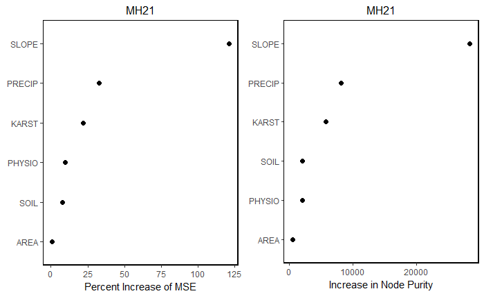

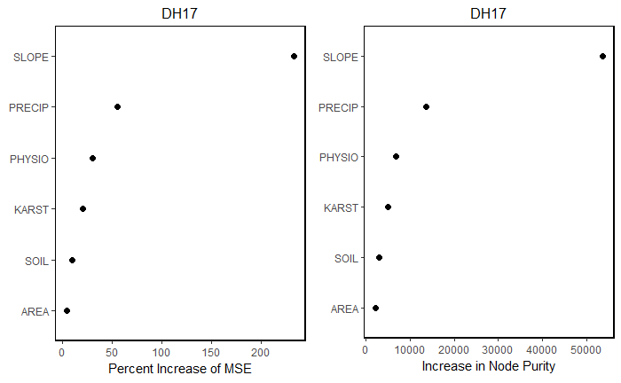

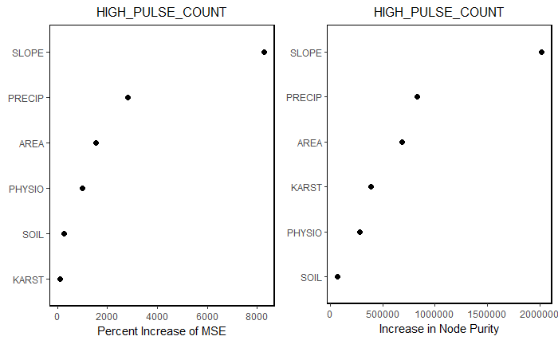

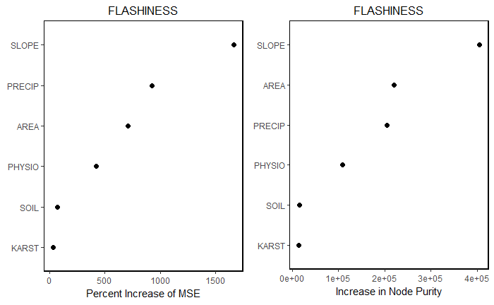

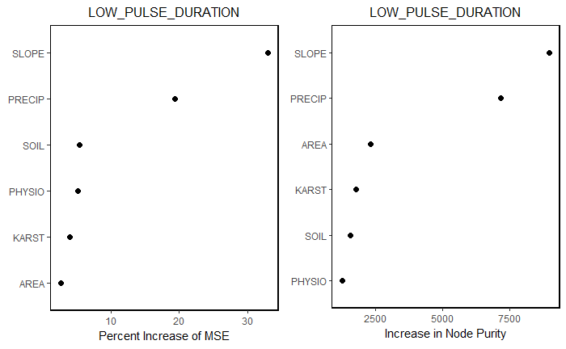

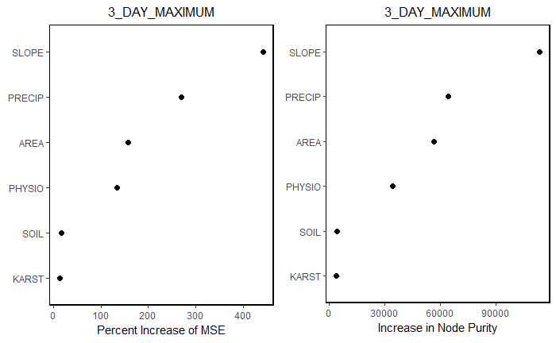

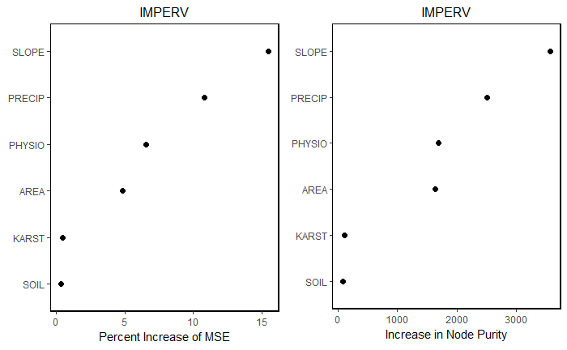

### Baseline/Impervious Scenario

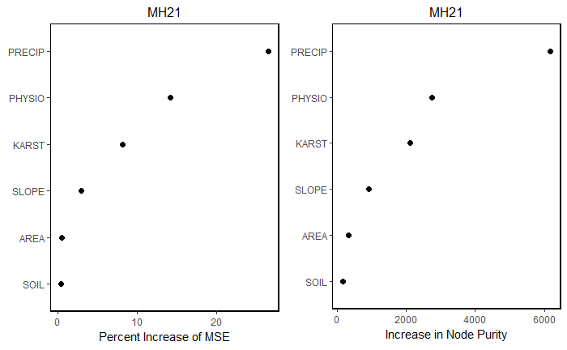

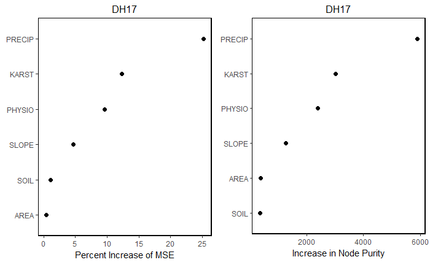

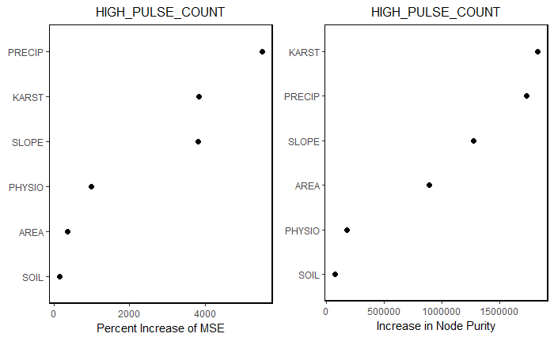

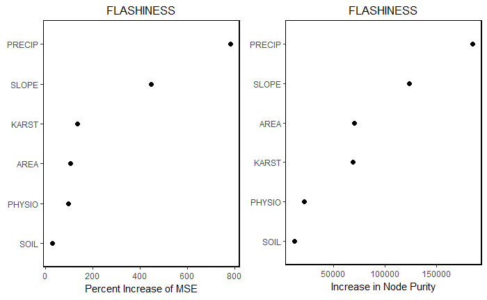

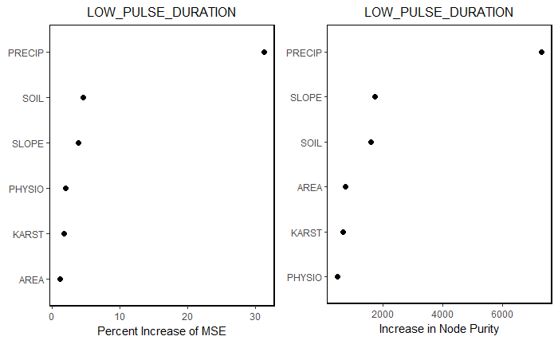

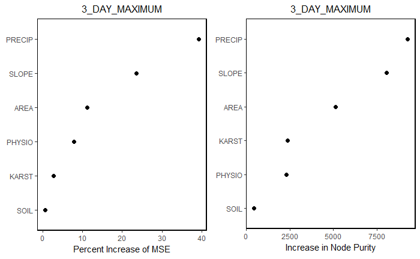

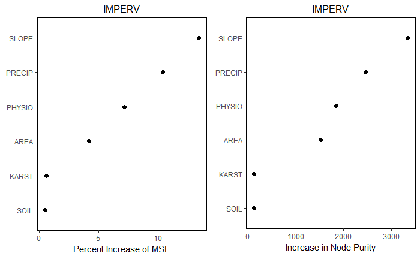

# Rpart

### Baseline/Current Scenario

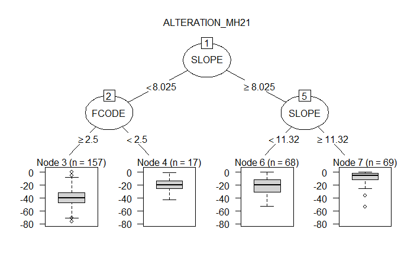

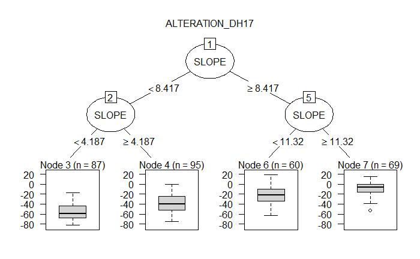

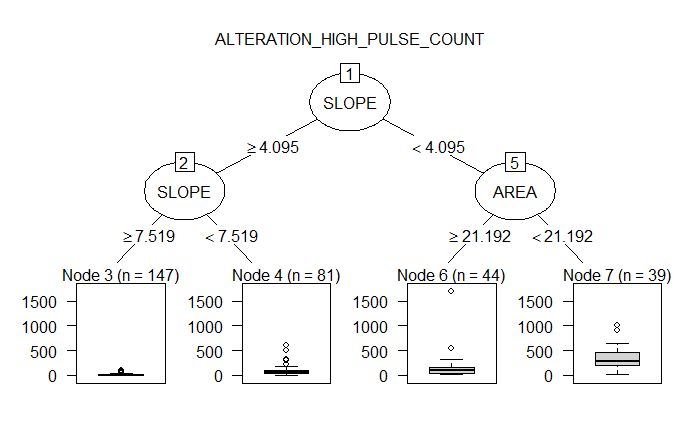

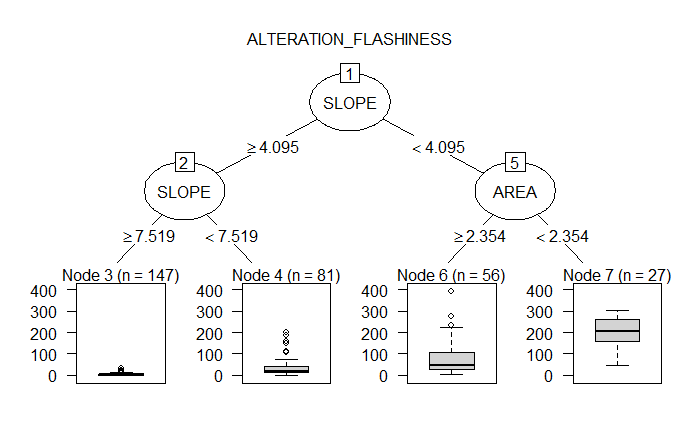

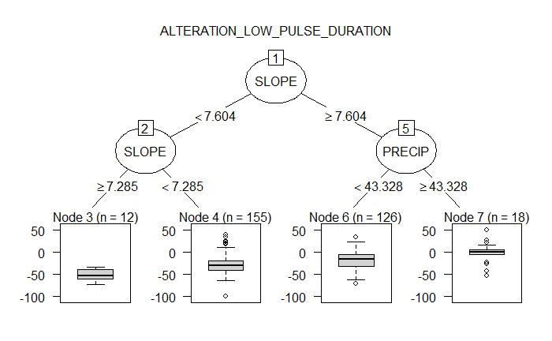

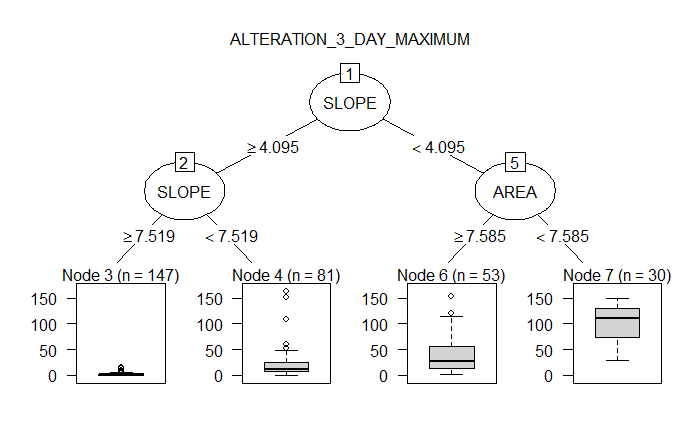

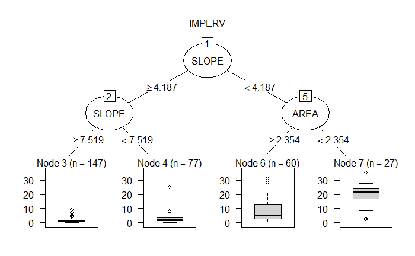

### Baseline/Impervious Scenario

```
There were missing values in resampled performance measures.
```

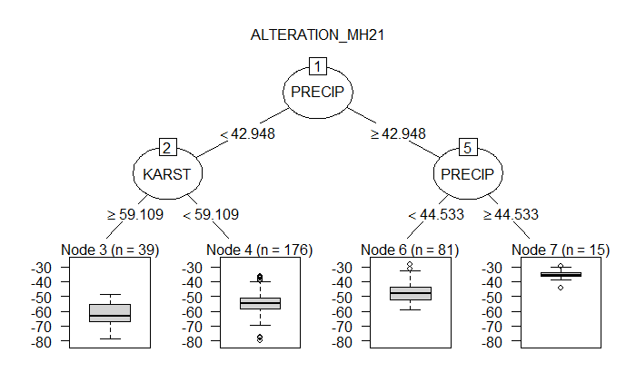

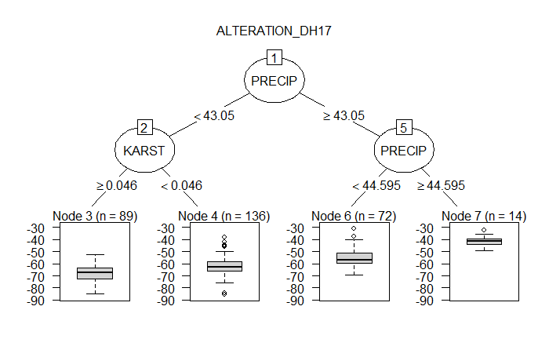

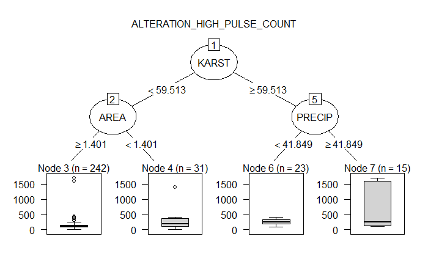

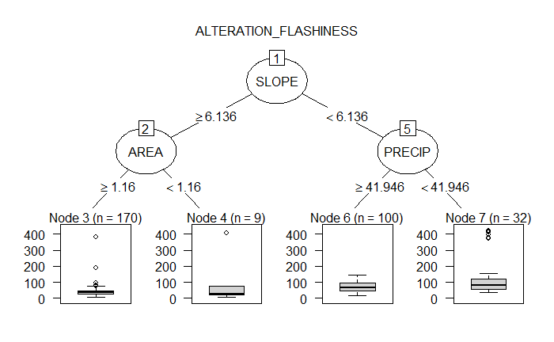

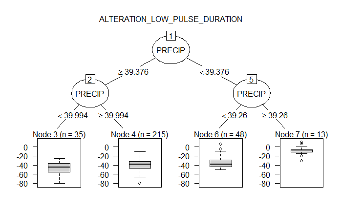

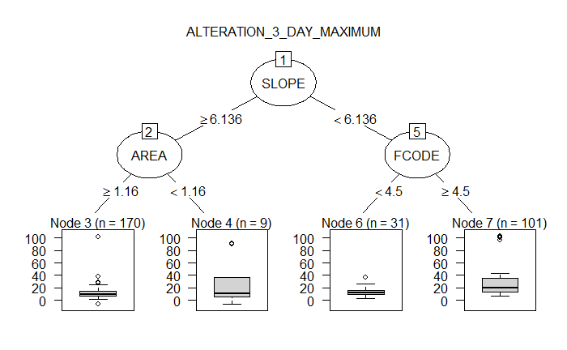

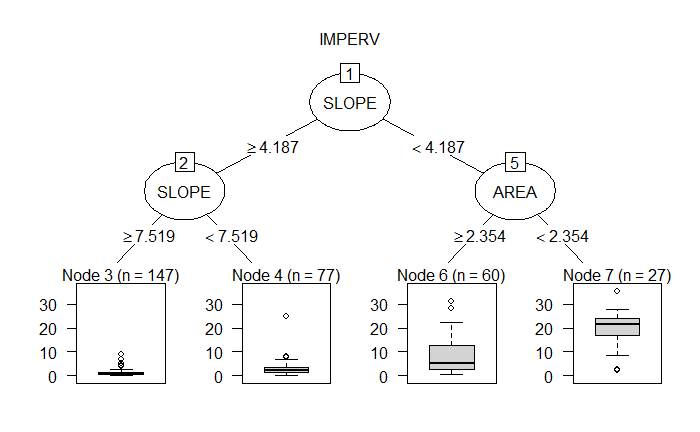